# Lecture 18 Closing Back Doors: Controlling

Nick Huntington-Klein

March 6, 2019

## Recap

- We discussed how to draw a causal diagram
- How to identify the front and back door paths
- And how we can close those back door paths by controlling/adjusting in order to identify the front-door paths we want!
- And so we get our causal effect

## Today

- Today we’re going to be going a little deeper into what it means to actually control/adjust for things
- And we’re also going to talk about times when controlling/adjusting makes things *WORSE* - collider bias!
- I’m going to just start saying “controlling”, by the way - “adjusting” is a little more accurate, but “controlling” is more common

## Controlling

- Up to now, here’s how we’ve been getting the relationship between `X` and `Y` while controlling for `W`:
1. See what part of `X` is explained by `W`, and subtract it out. Call the result the residual part of `X`.
2. See what part of `Y` is explained by `W`, and subtract it out. Call the result the residual part of `Y`.
3. Get the relationship between the residual part of `X` and the residual part of `Y`.
- With the last step including things like getting the correlation, plotting the relationship, calculating the variance explained, or comparing mean `Y` across values of `X`

## In code

```r
df <- tibble(w = rnorm(100)) %>%
  mutate(x = 2*w + rnorm(100)) %>%
  mutate(y = 1*x + 4*w + rnorm(100))
cor(df$x,df$y)
```

```
## [1] 0.9479742
```

```r
df <- df %>% group_by(cut(w,breaks=5)) %>%
  mutate(x.resid = x - mean(x),
         y.resid = y - mean(y))
cor(df$x.resid,df$y.resid)
```

```
## [1] 0.7367752
```

## In Diagrams

- The relationship between `X` and `Y` reflects both `X->Y` and `X<-W->Y`
- We remove the part of `X` and `Y` that `W` explains to get rid of `X<-W` and `W->Y`, blocking `X<-W->Y` and leaving `X->Y`

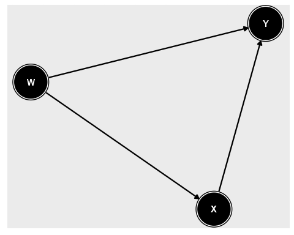

## More than One Variable

- It’s quite possible to control for more than one variable at a time
- Although we won’t be doing it much in this class
- A common way to do this is called multiple regression
- You can do it with our method too, but it gets tedious pretty quickly

## More than One Variable

```r
df <- tibble(w = rnorm(100),v=rnorm(100)) %>%
  mutate(x = 2*w + 3*v + rnorm(100)) %>%
  mutate(y = 1*x + 4*w + 1.5*v + rnorm(100))
cor(df$x,df$y)
```

```
## [1] 0.9340934
```

```r
df <- df %>% group_by(cut(w,breaks=5)) %>%
  mutate(x.resid = x - mean(x),
         y.resid = y - mean(y)) %>%
  group_by(cut(v,breaks=5)) %>%
  mutate(x.resid2 = x.resid - mean(x.resid),
         y.resid2 = y.resid - mean(y.resid))
cor(df$x.resid2,df$y.resid2)
```

```
## [1] 0.7419072
```

## Graphically

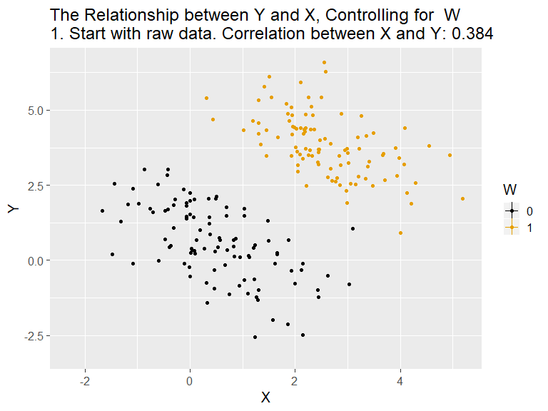

## Intuitively

- So what does this actually *mean*? Why do we do it this way?
- As mentioned before, the goal here is to remove `X<-W` and `W->Y` so as to close the back door
- But the way we actually *do* this is by removing differences that are *predicted* by `W`
- In other words, we are are *comparing people as though they had the same value of `W`*

## Intuitively

- That’s why you hear some people refer to controlling as “holding `W` constant” - we literally remove the variation in `W`, leaving it “constant”
- Another way of thinking of it is that you’re looking for variation of `X` and `Y` *within* values of `W` - this is made clear in the animation
- **Comparing apples to apples**

## Intuitively

- Thinking about it this way also makes it clear that there are other ways to control for things besides the method we’ve outlined
- Anything that ensures that we’re looking at observations with the *same* (or at least very very similar) values of `W` is in effect controlling for `W`
- A common way this happens is by selecting a sample

## An Example

- We’ll borrow an example from the Wooldridge econometrics textbook (data available in the `wooldridge` package)
- LaLonde (1986) is a study of whether a job training program improves earnings in 1978 (`re78`)
- Specifically, it has data on an *experiment* of *assigning* people to a job training program (data `jtrain2`)
- And also data on people who *chose* to participate in that program, or didn’t (data `jtrain3`)
- The goal of causal inference - do something to `jtrain3` so it gives us the “correct” result from `jtrain2`

## LaLonde

```r
library(wooldridge)
#EXPERIMENT
data(jtrain2)
jtrain2 %>% group_by(train) %>% summarize(wage = mean(re78))
```

```
## # A tibble: 2 x 2
##   train  wage
##   <int> <dbl>
## 1     0  4.55
## 2     1  6.35
```

```r
#BY CHOICE
data(jtrain3)
jtrain3 %>% group_by(train) %>% summarize(wage = mean(re78))
```

```
## # A tibble: 2 x 2
##   train  wage
##   <int> <dbl>
## 1     0 21.6
## 2     1  6.35
```

## Hmm…

- What back doors might the `jtrain3` analysis be facing?
- People who need training want to get it but are likely to get lower wages anyway!

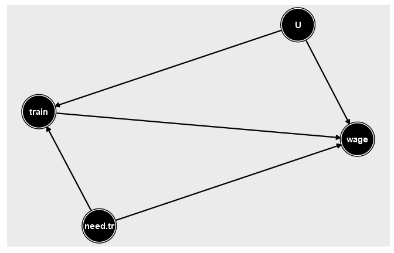

## Apples to Apples

- The two data sets are looking at very different groups of people!

```r
library(stargazer)
stargazer(select(jtrain2,re75,re78),type='text')
stargazer(select(jtrain3,re75,re78),type='text')
```

```
##
## ===========================================================
## Statistic  N  Mean  St. Dev.  Min  Pctl(25) Pctl(75)  Max
## -----------------------------------------------------------
## re75      445 1.377  3.151     0      0       1.2      25
## re78      445 5.301  6.631   0.000  0.000    8.125   60.308
## -----------------------------------------------------------
```

```
##
## ===============================================================
## Statistic   N    Mean  St. Dev.  Min  Pctl(25) Pctl(75)   Max
## ---------------------------------------------------------------
## re75      2,675 17.851  13.878    0     7.6      25.6     157
## re78      2,675 20.502  15.633  0.000  9.243    28.816  121.174
## ---------------------------------------------------------------
```

## Controlling

- We can’t measure “needs training” directly, but we can sort of control for it by limiting ourselves solely to the kind of people who need it - those who had low wages in 1975!

```
## # A tibble: 2 x 2
##   train  wage
##   <int> <dbl>
## 1     0  4.55
## 2     1  6.35
```

```
## # A tibble: 2 x 2
##   train  wage
##   <int> <dbl>
## 1     0  5.62
## 2     1  6.00
```

## Controlling

- Not exactly the same (not surprising - we were pretty arbitrary in how we controlled for `need.tr`, and we never closed `train <- U -> wage`, oh and we left out plenty of other back doors: race, age, etc.) but an improvement
- This goes to show that choosing a sample is a *form* of controlling
- ANYTHING that ensures you’re looking at observations with similar values of `W` is a form of controlling for `W`

## Bad Controls

- So far so good - we have the concept of what it means to control and some ways we can do it, so we can get apples-to-apples comparisons
- But what should we control for?
- Everything, right? We want to make sure our comparison is as apple-y as possible!
- Well, no, not actually

## Bad Controls

- Some controls can take you away from showing you the front door
- We already discussed how it’s not a good idea to block a front-door path.
- An increase in the price of cigarettes might improve your health, but not if we control for the number of cigarettes you smoke!

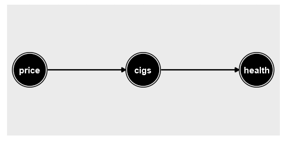

## Bad Controls

- There is another kind of bad control - a *collider*
- Basically, if you’re listing out paths, and you see a path where the arrows *collide* by both pointing at the same variable, **that path is already blocked**
- Like this: `X <- W -> C <- Z -> Y`
- Note the `-> C <-`. Those arrow are colliding!
- If we control for the collider `C`, *that path opens back up!*

## Colliders

- One kind of diagram (of many) where this might pop up:

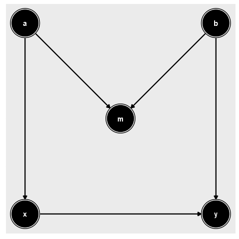

## Colliders

- How could this be?
- Because even if two variables *cause* the same thing (`a -> m`, `b -> m`), that doesn’t make them related. Your parents both caused your genetic makeup, that doesn’t make *their* genetics related. Knowing dad’s eye color tells you nothing about mom’s.
- But *within given values of the collider*, they ARE related. If you’re brown-eyed, then observing that your dad has blue eyes tells us that your mom is brown-eyed

## Colliders

- So here, `x <- a -> m <- b -> y` is pre-blocked, no problem. `a` and `b` are unrelated, so no back door issue!
- Control for `m` and now `a` and `b` are related, back door path open.

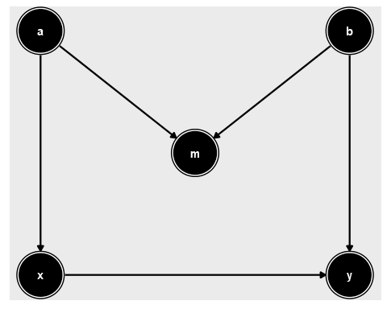

## Example

- You want to know if programming skills reduce your social skills
- So you go to a tech company and test all their employees on programming and social skills
- Let’s imagine that the *truth* is that programming skills and social skills are unrelated
- But you find a negative relationship! What gives?

## Example

- Oops! By surveying only the tech company, you controlled for “works in a tech company”
- To do that, you need programming skills, social skills, or both! It’s a collider!

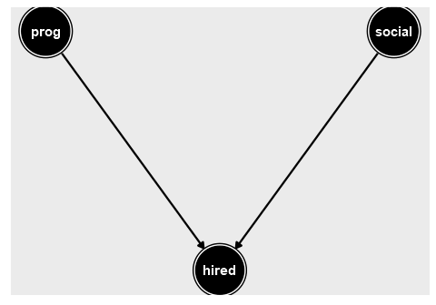

## Example

```r
set.seed(14233)
survey <- tibble(prog=rnorm(1000),social=rnorm(1000)) %>%
  mutate(hired = (prog + social > .25))
#Truth
cor(survey$prog,survey$social)
```

```
## [1] 0.03710333
```

```r
#Controlling by just surveying those hired
cor(filter(survey,hired==1)$prog,filter(survey,hired==1)$social)
```

```
## [1] -0.4789209
```

```r
#Surveying everyone and controlling with our normal method
survey <- survey %>% group_by(hired) %>%  mutate(p.resid = prog - mean(prog),
         s.resid = social - mean(social)) %>% ungroup()
cor(survey$p.resid,survey$s.resid)
```

```
## [1] -0.4268598
```

## Graphically

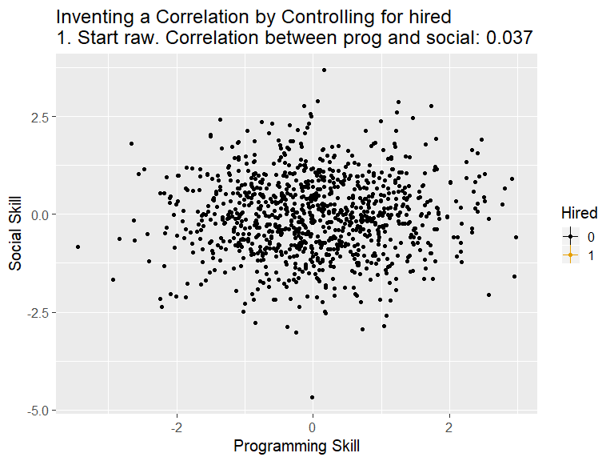

## Colliders

- This doesn’t just create correlations from nothing, it can also distort causal effects that ARE there
- For example, did you know that height is UNrelated to basketball skill… among NBA players?

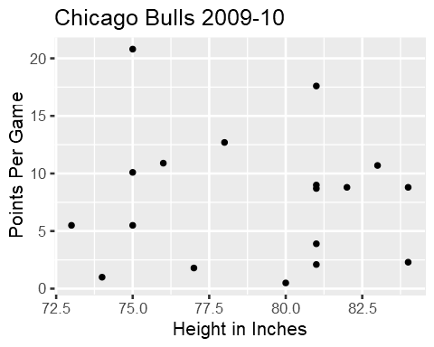

## Colliders

- Sometimes, things can get real tricky
- In some cases, the same variable NEEDS to be controlled for to close a back door path, but it’s a collider on ANOTHER back door path!
- In those cases you just can’t identify the effect, at least not easily
- This pops up in estimates of the gender wage gap - example from Cunningham’s Mixtape: should you control for occupation when looking at gender discrimination in the labor market?

## Colliders in the Gender Wage Gap

- We are interested in `gender -> discrim -> wage`; our treatment is `gender -> discrim`, the discrimination caused by your gender

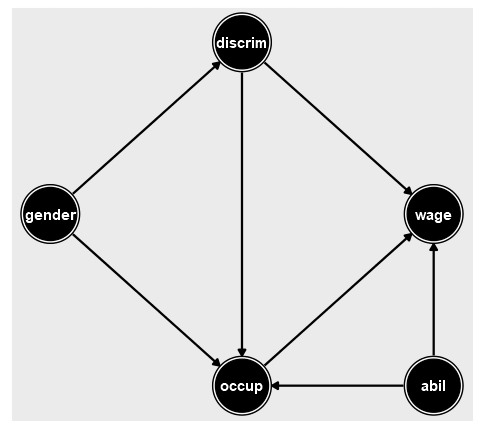

## Colliders in the Gender Wage Gap

- Front doors/Open back doors/Closed back doors
- `gender -> discrim -> wage`
- `gender -> discrim -> occup -> wage`
- `discrim <- gender -> occup -> wage`
- `discrim <- gender -> occup <- abil -> wage`
- `gender -> discrim -> occup <- abil -> wage`

## Colliders in the Gender Wage Gap

- No `occup` control? Ignore nondiscriminatory reasons to choose different occupations by gender
- Control for `occup`? Open both back doors, create a correlation between `abil` and `discrim` where there wasn’t one
- And also close a FRONT door, `gender -> discrim -> occup -> wage`: discriminatory reasons for gender diffs in `occup`
- We actually *can’t* identify the effect we want in this diagram by controlling. It happens!
- Suggests this question goes beyond just controlling for stuff. Real research on this topic gets clever.

## Next Time

- Get ready! Next time we’ll begin our trek down the list of common causal inference methods as they actually get used!
- Many of them apply controlling for stuff in interesting ways
- Others use methods other than controlling!
- This is what economists and many data scientists actually do with their time
- We will begin with “fixed effects”